# Evaluating the correlation between various water contaminants throughout the Ellerbe Creek Watershed

https://github.com/joa-kenit/EDAProject2023

Joanna Huertas

Spring 2023

# Introduction

The growing demand for freshwater coupled with human activities has resulted in increased water pollution. Water contamination is a significant environmental concern, with potential health risks to humans and wildlife. The Ellerbe Creek Watershed, located in North Carolina, is home to diverse aquatic species and provides drinking water to local communities. However, it is also vulnerable to water contamination from various sources, including agriculture, urban runoff, and industrial activities.

This project aims to evaluate the correlation between various water contaminants throughout the Ellerbe Creek Watershed. The study will investigate the presence and levels of contaminants such as heavy metals in the water, and analyze the relationship between these contaminants. The findings of this study could provide valuable insights into the impact of water contamination on the environment and human health, and help identify potential sources of pollution in the watershed.

# Rationale and Research Questions

### Research question:

Is there a correlation between water quality parameters in the Ellerbe Creek?

### Rationale:

Understanding the correlation between different water contaminants in the Ellerbe Creek is essential to identify potential sources of pollution and implement effective management strategies to protect the environment and public health.

# Dataset Information

[output not shown]

Find the metadata in /Data/Raw in the .tex file

# Exploration Raw Data

Reading dataset:

Exploring dimensions and each column of the dataset:

```
##  [1] "id"                    "Station.Name"          "Filtered"
##  [4] "Parameter"             "Date.Time"             "Value"
##  [7] "QA.Code"               "Unit"                  "QAQC.Sample"
## [10] "Comments"              "Rain.in.Last.24.Hours" "Sky.Condition"
## [13] "Flow.Severity"         "Comp..Code"            "Thalweg"
## [16] "Lab"                   "Project"
```

```
## 'data.frame':    21661 obs. of  17 variables:
##  $ id                   : int  1 2 3 4 5 6 7 8 9 10 ...
##  $ Station.Name         : Factor w/ 8 levels "EL1.9EC","EL5.5GC",..: 7 1 1 1 1 1 1 1 1 1 ...
##  $ Filtered             : Factor w/ 4 levels "","Field","Lab",..: 4 1 1 1 1 1 1 1 1 1 ...
##  $ Parameter            : Factor w/ 34 levels "Alkalinity","Aluminum",..: 1 1 1 1 1 1 1 1 1 1 ...
##  $ Date.Time            : Factor w/ 1177 levels "1/10/2005 10:12",..: 542 487 519 664 722 814 960 1078 1093 114 ...
##  $ Value                : num  78 61.2 61.4 76.9 46.5 51.3 64.4 47.5 52.4 60 ...
##  $ QA.Code              : Factor w/ 30 levels "","B,B3","B1",..: 1 1 1 1 1 1 1 1 1 1 ...
##  $ Unit                 : Factor w/ 10 levels "","%","C","cfu/100mL",..: 1 7 7 7 7 7 7 7 7 7 ...
##  $ QAQC.Sample          : Factor w/ 2 levels "","Duplicate": 1 1 1 1 1 1 1 1 1 1 ...
##  $ Comments             : Factor w/ 194 levels "","13WQ271","13WQ299",..: 136 1 1 1 1 1 1 1 1 1 ...
##  $ Rain.in.Last.24.Hours: Factor w/ 3 levels "","No","Yes": 2 1 1 1 1 1 1 1 1 1 ...
##  $ Sky.Condition        : Factor w/ 5 levels "","Cloudy","Overcast",..: 5 4 4 5 5 2 5 5 2 5 ...
##  $ Flow.Severity        : int  2 NA NA NA NA NA NA NA NA NA ...
##  $ Comp..Code           : Factor w/ 2 levels "","G": 2 2 2 2 2 2 2 2 2 2 ...
##  $ Thalweg              : Factor w/ 3 levels "","No","Yes": 3 1 1 1 1 1 1 1 1 1 ...
##  $ Lab                  : Factor w/ 3 levels "","ENCO","SDWRF": 3 3 3 3 3 3 3 3 3 3 ...
##  $ Project              : Factor w/ 2 levels "Ambient","Ambient&10-013": 1 1 1 1 1 1 1 1 1 1 ...
```

```
## $id
## [1] 1 2 3 4 5 6
##
## $Station.Name
## [1] EL8.5SEC EL1.9EC  EL1.9EC  EL1.9EC  EL1.9EC  EL1.9EC
## 8 Levels: EL1.9EC EL5.5GC EL5.6EC EL7.1EC EL7.1SEC EL8.1GC ... EL8.6SECUT
##
## $Filtered
## [1] No
## Levels:  Field Lab No
##
## $Parameter
## [1] Alkalinity Alkalinity Alkalinity Alkalinity Alkalinity Alkalinity
## 34 Levels: Alkalinity Aluminum Ammonia Nitrogen ... Zinc
##
## $Date.Time
## [1] 3/16/2016 8:46 2/7/2006 9:10  3/14/2006 9:25 4/4/2006 9:47  5/16/2006 9:05
## [6] 6/13/2006 9:26
## 1177 Levels: 1/10/2005 10:12 1/10/2005 10:32 1/10/2005 8:55 ... 9/9/2014 9:40
##
## $Value
## [1] 78.0 61.2 61.4 76.9 46.5 51.3
##
## $QA.Code
## [1]
## 30 Levels:  B,B3 B1 B2 B4 B5 B5,J7 G11 G5 G7 G8 J J,J2 J,J7 J,J7,J2 J10 ... X3
##
## $Unit
## [1]           mgCaCO3/L mgCaCO3/L mgCaCO3/L mgCaCO3/L mgCaCO3/L
## Levels:  % C cfu/100mL ft mg/L mgCaCO3/L NTU ug/L uS/cm at 25 deg C
##
## $QAQC.Sample
## [1]
## Levels:  Duplicate
##
## $Comments
## [1] Staff Gage:  0.72
## [5]
## 194 Levels:  13WQ271 13WQ299 ... WQ INVEST: 11WQ181
##
```

[output cut: 12 more lines]

```
## $Comp..Code
## [1] G G G G G G
## Levels:  G
##
## $Thalweg
## [1] Yes
## Levels:  No Yes
##
## $Lab
## [1] SDWRF SDWRF SDWRF SDWRF SDWRF SDWRF
## Levels:  ENCO SDWRF
##
## $Project
## [1] Ambient Ambient Ambient Ambient Ambient Ambient
## Levels: Ambient Ambient&10-013
```

# Data Wrangling Analysis

After exploring the raw data, we have enough information and we have the need to wrangle the data to easily analyze the trends of our data, and this includes:

- Change date columns to be date objects
- Drop “NA” values
- Save the processed dataset in the Processed folder.
- Select only the useful columns
- Adding columns for months and years

The relevant columns were selected before getting the final dataset. This dataset was saved as “water.durham.wrangle” and used for subsequent analyses.

These are the set of Parameters we have:

```
##  [1] Alkalinity                  Aluminum
##  [3] Ammonia Nitrogen            Biochemical Oxygen Demand
##  [5] Cadmium                     Calcium
##  [7] Chloride                    Chromium
##  [9] Conductivity                Copper
## [11] Dissolved Oxygen            Dissolved Oxygen Saturation
## [13] Fecal Coliform              Fluoride
## [15] Gage height                 Hardness
## [17] Iron                        Lead
## [19] Magnesium                   Manganese
## [21] Nickel                      Nitrate + Nitrite as N
## [23] Organic Carbon              Orthophosphorus
## [25] pH                          Potassium
## [27] Sodium                      Sulfate
## [29] Temperature                 Total Kjeldahl Nitrogen
## [31] Total Phosphorus            Total Suspended Solids
## [33] Turbidity                   Zinc
## 34 Levels: Alkalinity Aluminum Ammonia Nitrogen ... Zinc
```

# Exploring processed dataset

This is the summary of our dataset “water.durham.wrangle”:

```
##        id            Station.Name                        Parameter
##  Min.   :    1   EL1.9EC   :4550   Copper                     : 2053
##  1st Qu.: 5418   EL8.1GC   :3024   Zinc                       : 1236
##  Median :10832   EL7.1SEC  :2698   Fecal Coliform             : 1224
##  Mean   :10832   EL5.6EC   :2682   Conductivity               : 1186
##  3rd Qu.:16246   EL8.6SECUT:2654   Dissolved Oxygen           : 1186
##  Max.   :21661   EL8.5SEC  :2386   Dissolved Oxygen Saturation: 1186
##                  (Other)   :3665   (Other)                    :13588
##       Date                Value                 Unit            Sky.Condition
##  Min.   :2004-01-20   Min.   :     0.0   mg/L     :8552                : 124
##  1st Qu.:2009-05-12   1st Qu.:     2.5   ug/L     :5809   Cloudy       :2128
##  Median :2013-09-10   Median :     8.0   cfu/100mL:1224   Overcast     :4300
##  Mean   :2013-10-02   Mean   :  1616.7            :1187   Partly Cloudy:5492
##  3rd Qu.:2018-06-05   3rd Qu.:    80.6   %        :1186   Sunny        :9615
##  Max.   :2022-06-07   Max.   :120000.0   C        :1186
##                                          (Other)  :2515
##      Month             Year
##  Min.   : 1.000   2019   : 2137
##  1st Qu.: 3.000   2017   : 1999
##  Median : 6.000   2021   : 1843
##  Mean   : 6.452   2015   : 1739
##  3rd Qu.: 9.000   2011   : 1543
##  Max.   :12.000   2010   : 1490
##                   (Other):10908
```

## Question: Is there a correlation between water quality parameters in the Ellerbe Creek?

H0 : There is no significant correlation between certain parameters. HA : There is a significant correlation between certain parameters.

The pairs of parameters chosen, based on previous studies (see references) and general knowledge, are the following:

- Chloride and Fluoride
- BOD and DO
- Temperature and Dissolved Oxygen (DO)
- Biochemical Oxygen Demand (BOD) and Organic Carbon
- Iron and manganese
- Iron and dissolved oxygen
- Nitrate + nitrite and dissolved oxygen
- Total suspended solids + turbidity
- Total suspended solid + conductivity
- Phosphorus and nitrate
- Total Kjeldahl Nitrogen and Nitrate+Nitrite Concentration
- Chloride and total suspended solid
- Chloride and Fluoride
- Lead and pH
- pH and ammonia nitrogen

After creating a custom plot theme, we got some plots of individual parameters, a function was created to do so.

## Exploring individual trends

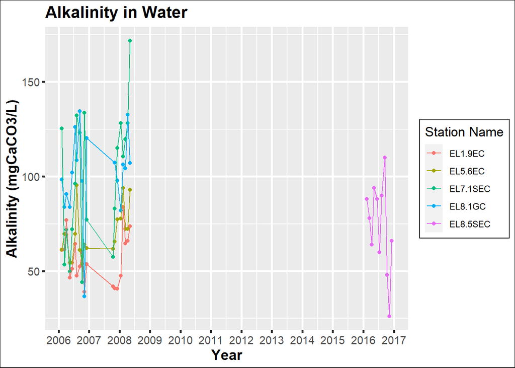

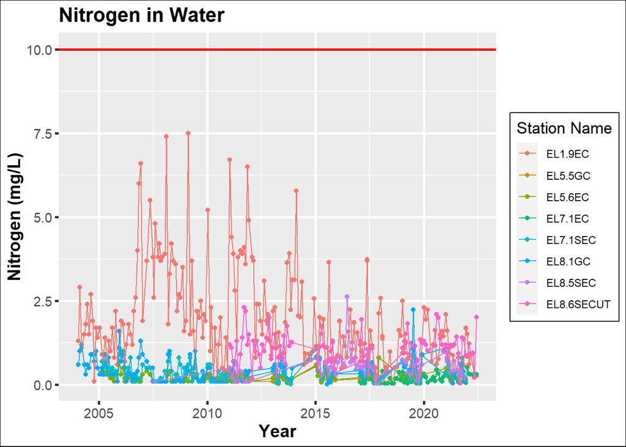

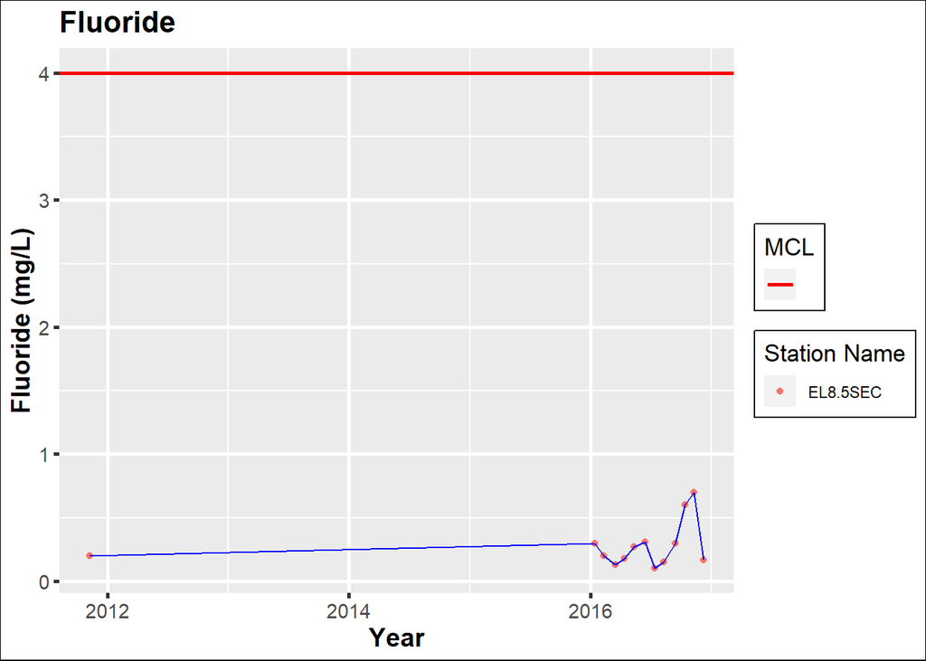

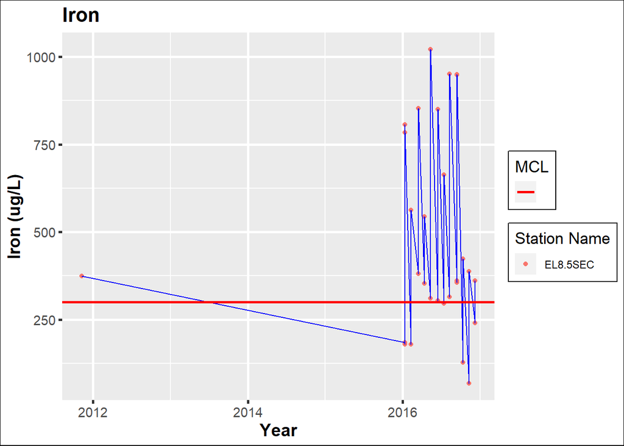

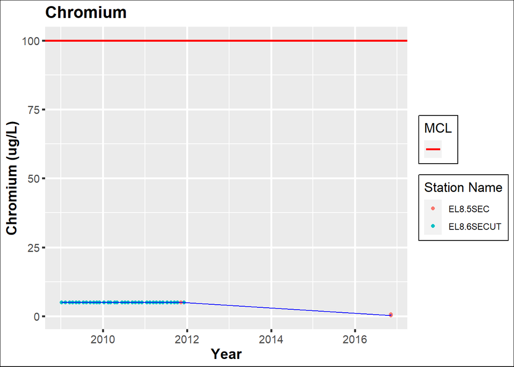

## Visualization of possible correlations between 2 parameters for each available station

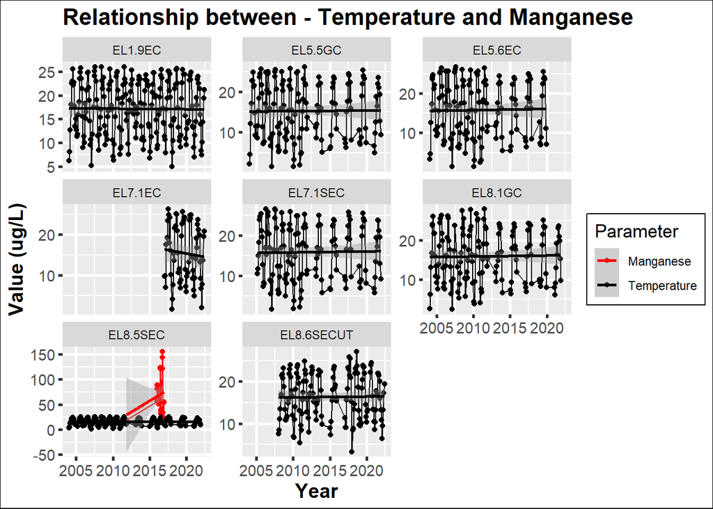

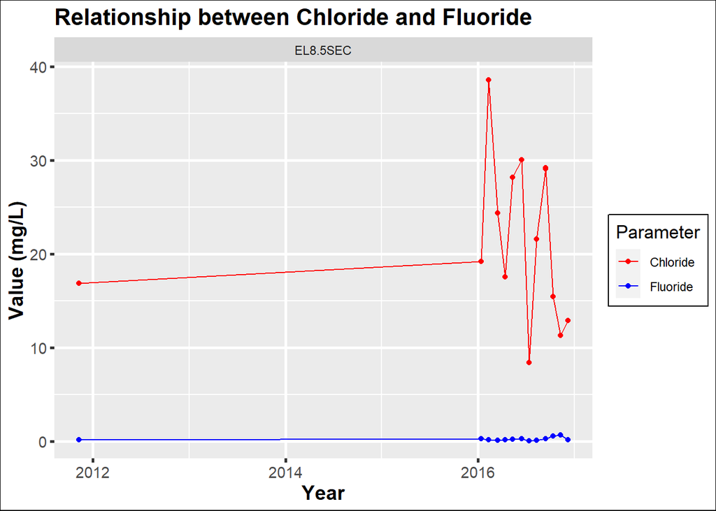

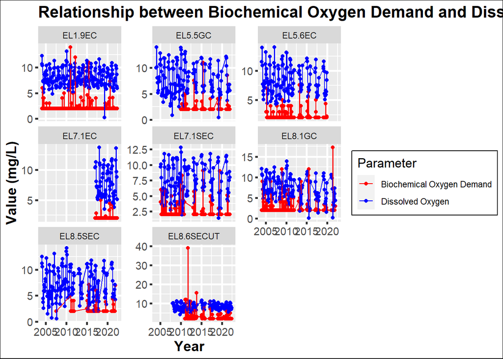

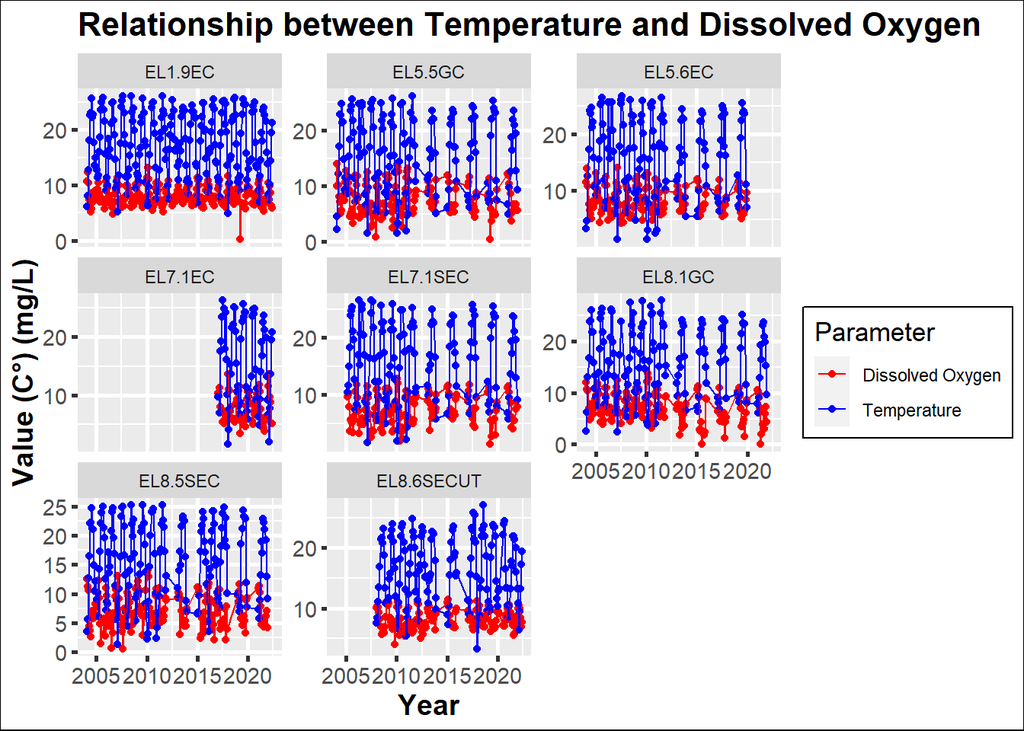

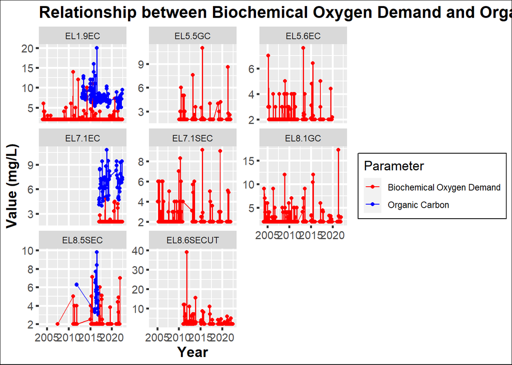

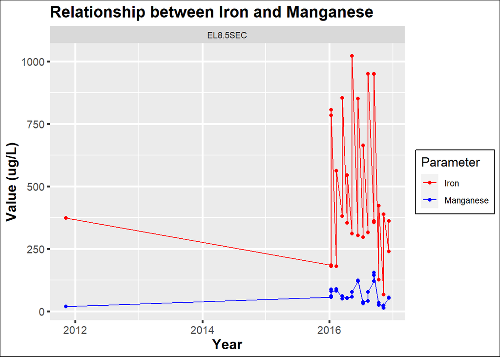

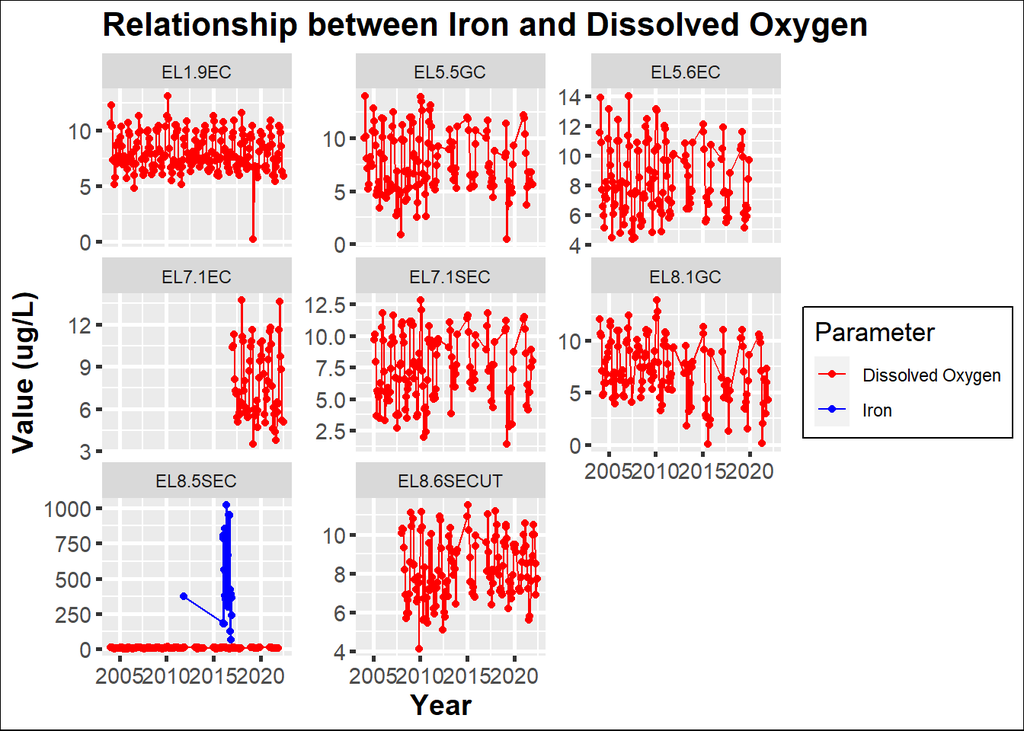

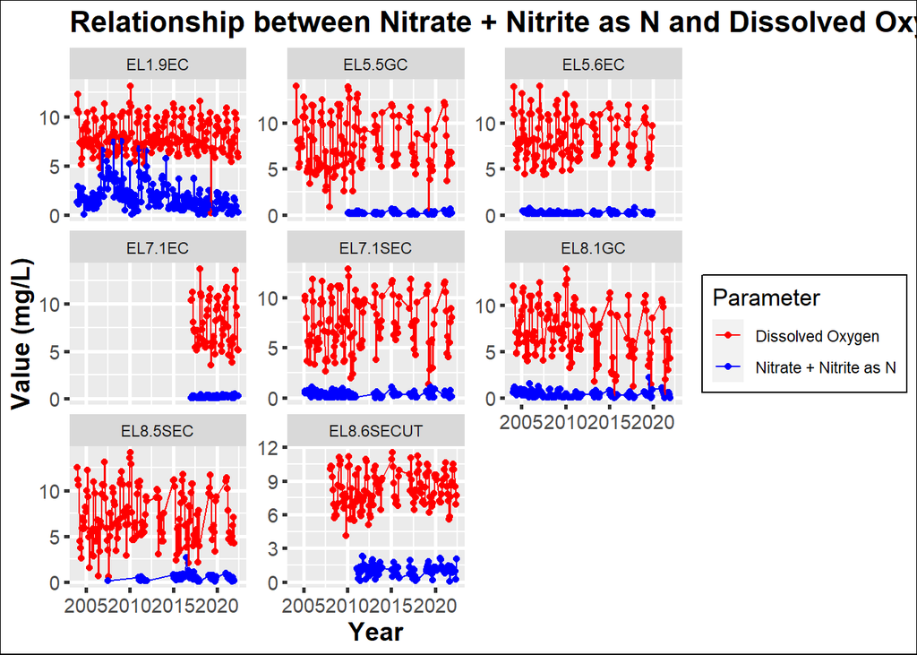

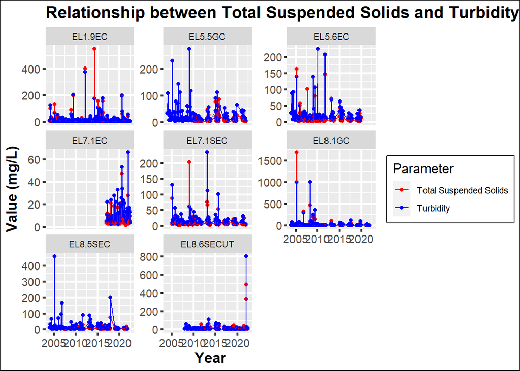

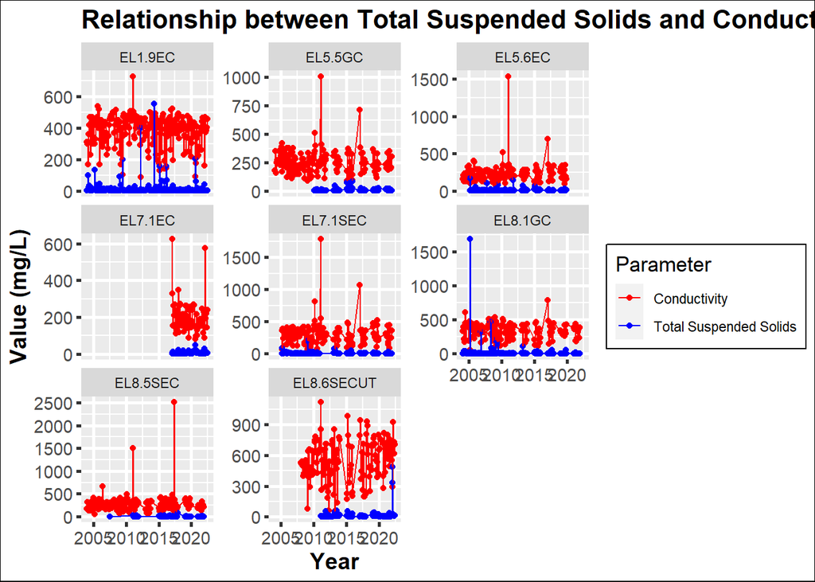

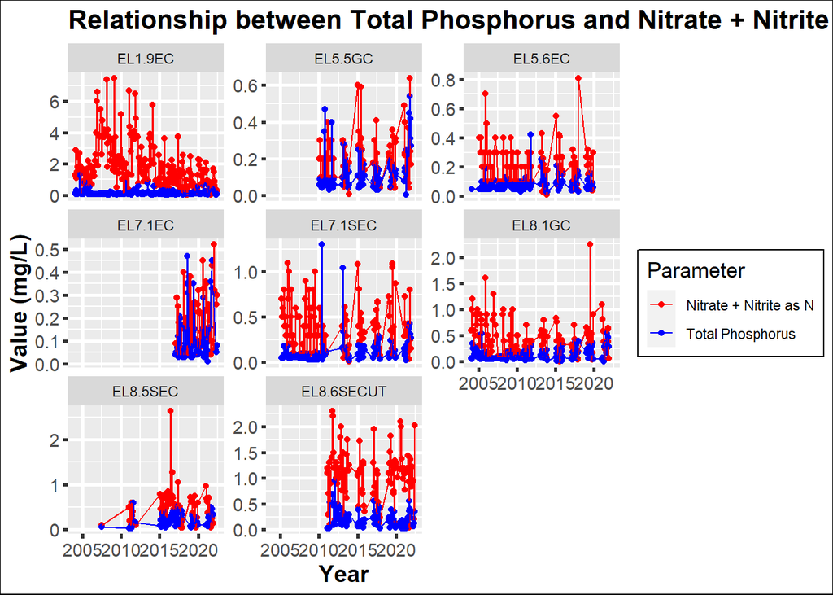

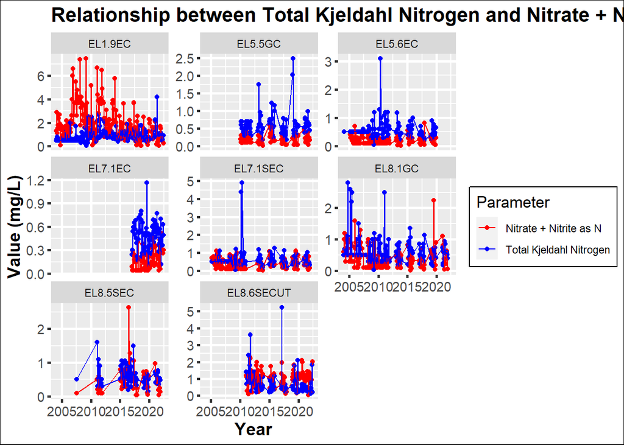

[3 more figures not shown]

## Visualization

Visualizing the relationship among two variables with a scatter plot of chloride by fluoride.

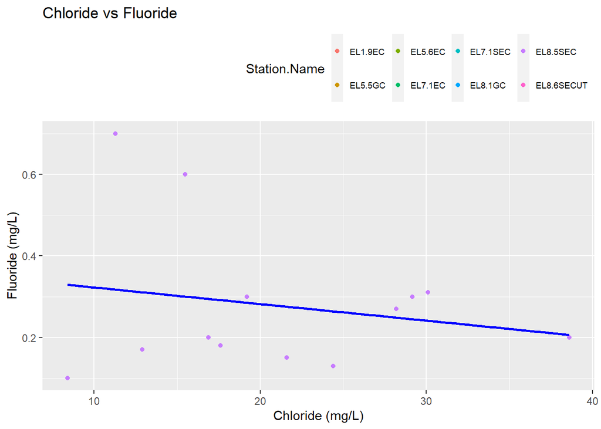

In this case, the scatterplot suggests that there could be a negative relationship between chloride and fluoride. ## Linear Regression Analysis

```
##
## Call:
## lm(formula = Chloride ~ Fluoride, data = wide_data)
##
## Residuals:
##     Min      1Q  Median      3Q     Max
## -14.351  -4.902  -1.654   7.062  16.798
##
## Coefficients:
##             Estimate Std. Error t value Pr(>|t|)
## (Intercept)   23.699      4.668   5.077 0.000357 ***
## Fluoride      -9.485     14.277  -0.664 0.520116
## ---
## Signif. codes:  0 '***' 0.001 '**' 0.01 '*' 0.05 '.' 0.1 ' ' 1
##
## Residual standard error: 8.884 on 11 degrees of freedom
##   (1175 observations deleted due to missingness)
## Multiple R-squared:  0.03858,    Adjusted R-squared:  -0.04882
## F-statistic: 0.4414 on 1 and 11 DF,  p-value: 0.5201
```

```
##
## Call:
## lm(formula = Biochemical.Oxygen.Demand ~ Dissolved.Oxygen, data = wide_data)
##
## Residuals:
##    Min     1Q Median     3Q    Max
## -1.255 -0.773 -0.617 -0.333 36.263
##
## Coefficients:
##                  Estimate Std. Error t value Pr(>|t|)
## (Intercept)       3.26931    0.22898  14.278  < 2e-16 ***
## Dissolved.Oxygen -0.07353    0.02848  -2.581  0.00999 **
## ---
## Signif. codes:  0 '***' 0.001 '**' 0.01 '*' 0.05 '.' 0.1 ' ' 1
##
## Residual standard error: 2.061 on 937 degrees of freedom
##   (249 observations deleted due to missingness)
## Multiple R-squared:  0.007061,   Adjusted R-squared:  0.006001
## F-statistic: 6.663 on 1 and 937 DF,  p-value: 0.009994
```

```
##
## Call:
## lm(formula = Temperature ~ Dissolved.Oxygen, data = wide_data)
##
## Residuals:
##      Min       1Q   Median       3Q      Max
## -23.2654  -2.2603   0.1559   2.8255  10.2118
##
## Coefficients:
##                  Estimate Std. Error t value Pr(>|t|)
## (Intercept)      31.49909    0.40386   78.00   <2e-16 ***
## Dissolved.Oxygen -2.01598    0.05009  -40.24   <2e-16 ***
## ---
## Signif. codes:  0 '***' 0.001 '**' 0.01 '*' 0.05 '.' 0.1 ' ' 1
##
## Residual standard error: 4.237 on 1182 degrees of freedom
##   (4 observations deleted due to missingness)
## Multiple R-squared:  0.5781, Adjusted R-squared:  0.5777
## F-statistic:  1620 on 1 and 1182 DF,  p-value: < 2.2e-16
```

```
##
## Call:
## lm(formula = Biochemical.Oxygen.Demand ~ Organic.Carbon, data = wide_data)
##
## Residuals:
##     Min      1Q  Median      3Q     Max
## -0.9209 -0.3397 -0.2724 -0.1671  8.5330
##
## Coefficients:
##                Estimate Std. Error t value Pr(>|t|)
## (Intercept)     1.70503    0.40078   4.254 3.77e-05 ***
## Organic.Carbon  0.08106    0.05428   1.493    0.138
## ---
## Signif. codes:  0 '***' 0.001 '**' 0.01 '*' 0.05 '.' 0.1 ' ' 1
##
## Residual standard error: 1.118 on 143 degrees of freedom
##   (1043 observations deleted due to missingness)
## Multiple R-squared:  0.01535,    Adjusted R-squared:  0.008469
## F-statistic:  2.23 on 1 and 143 DF,  p-value: 0.1376
```

```
##
## Call:
## lm(formula = Iron ~ Dissolved.Oxygen, data = wide_data)
##
## Residuals:
##     Min      1Q  Median      3Q     Max
## -220.77  -42.42   24.09   86.08  188.51
##
## Coefficients:
##                  Estimate Std. Error t value Pr(>|t|)
## (Intercept)        679.39     109.21   6.221 6.52e-05 ***
## Dissolved.Oxygen   -28.18      13.82  -2.039   0.0662 .
## ---
## Signif. codes:  0 '***' 0.001 '**' 0.01 '*' 0.05 '.' 0.1 ' ' 1
##
## Residual standard error: 135.3 on 11 degrees of freedom
##   (1175 observations deleted due to missingness)
## Multiple R-squared:  0.2744, Adjusted R-squared:  0.2084
## F-statistic: 4.159 on 1 and 11 DF,  p-value: 0.06616
```

```
##
## Call:
## lm(formula = Iron ~ Fluoride, data = wide_data)
##
## Residuals:
##     Min      1Q  Median      3Q     Max
## -216.34  -67.14  -55.74  107.50  193.42
##
## Coefficients:
##             Estimate Std. Error t value Pr(>|t|)
## (Intercept)   590.42      71.76   8.228    5e-06 ***
## Fluoride     -432.80     219.47  -1.972   0.0743 .
## ---
## Signif. codes:  0 '***' 0.001 '**' 0.01 '*' 0.05 '.' 0.1 ' ' 1
##
## Residual standard error: 136.6 on 11 degrees of freedom
##   (1175 observations deleted due to missingness)
## Multiple R-squared:  0.2612, Adjusted R-squared:  0.194
## F-statistic: 3.889 on 1 and 11 DF,  p-value: 0.07428
```

```
##
## Call:
## lm(formula = Nitrate...Nitrite.as.N ~ Dissolved.Oxygen, data = wide_data)
##
## Residuals:
##     Min      1Q  Median      3Q     Max
## -1.0852 -0.5522 -0.3264  0.1474  6.6004
##
## Coefficients:
##                  Estimate Std. Error t value Pr(>|t|)
## (Intercept)       0.28026    0.10925   2.565   0.0105 *
## Dissolved.Oxygen  0.06168    0.01359   4.539  6.4e-06 ***
## ---
## Signif. codes:  0 '***' 0.001 '**' 0.01 '*' 0.05 '.' 0.1 ' ' 1
##
## Residual standard error: 0.9864 on 939 degrees of freedom
##   (247 observations deleted due to missingness)
## Multiple R-squared:  0.02147,    Adjusted R-squared:  0.02042
## F-statistic:  20.6 on 1 and 939 DF,  p-value: 6.395e-06
```

```
##
## Call:
## lm(formula = Total.Suspended.Solids ~ Turbidity, data = wide_data)
##
## Residuals:
##     Min      1Q  Median      3Q     Max
## -425.72   -2.34    0.72    2.77  791.28
##
## Coefficients:
##             Estimate Std. Error t value Pr(>|t|)
## (Intercept) -2.92718    1.28288  -2.282   0.0227 *
## Turbidity    0.90065    0.01987  45.325   <2e-16 ***
## ---
## Signif. codes:  0 '***' 0.001 '**' 0.01 '*' 0.05 '.' 0.1 ' ' 1
##
## Residual standard error: 37.25 on 935 degrees of freedom
##   (251 observations deleted due to missingness)
## Multiple R-squared:  0.6872, Adjusted R-squared:  0.6869
## F-statistic:  2054 on 1 and 935 DF,  p-value: < 2.2e-16
```

```
##
## Call:
## lm(formula = Total.Suspended.Solids ~ Conductivity, data = wide_data)
##
## Residuals:
##     Min      1Q  Median      3Q     Max
##  -25.09  -13.22   -9.16   -3.37 1662.07
##
## Coefficients:
##              Estimate Std. Error t value Pr(>|t|)
## (Intercept)  29.45018    4.51551   6.522 1.13e-10 ***
## Conductivity -0.04197    0.01189  -3.529 0.000438 ***
## ---
## Signif. codes:  0 '***' 0.001 '**' 0.01 '*' 0.05 '.' 0.1 ' ' 1
##
## Residual standard error: 65.99 on 940 degrees of freedom
##   (246 observations deleted due to missingness)
## Multiple R-squared:  0.01307,    Adjusted R-squared:  0.01202
## F-statistic: 12.45 on 1 and 940 DF,  p-value: 0.000438
```

```
##
## Call:
## lm(formula = Total.Phosphorus ~ Nitrate...Nitrite.as.N, data = wide_data)
##
## Residuals:
##      Min       1Q   Median       3Q      Max
## -0.13654 -0.07950 -0.04941  0.02548  1.16057
##
## Coefficients:
##                         Estimate Std. Error t value Pr(>|t|)
## (Intercept)            0.1393899  0.0055439  25.143   <2e-16 ***
## Nitrate...Nitrite.as.N 0.0004012  0.0044224   0.091    0.928
## ---
## Signif. codes:  0 '***' 0.001 '**' 0.01 '*' 0.05 '.' 0.1 ' ' 1
##
## Residual standard error: 0.1351 on 927 degrees of freedom
##   (259 observations deleted due to missingness)
## Multiple R-squared:  8.877e-06,  Adjusted R-squared:  -0.00107
## F-statistic: 0.008229 on 1 and 927 DF,  p-value: 0.9277
```

```
##
## Call:
## lm(formula = Total.Kjeldahl.Nitrogen ~ Nitrate...Nitrite.as.N,
##     data = wide_data)
##
## Residuals:
##     Min      1Q  Median      3Q     Max
## -0.8168 -0.2295 -0.1123  0.0998  4.4292
##
## Coefficients:
##                        Estimate Std. Error t value Pr(>|t|)
## (Intercept)             0.60263    0.01927  31.274  < 2e-16 ***
## Nitrate...Nitrite.as.N  0.09651    0.01546   6.241 6.61e-10 ***
## ---
## Signif. codes:  0 '***' 0.001 '**' 0.01 '*' 0.05 '.' 0.1 ' ' 1
##
## Residual standard error: 0.4665 on 925 degrees of freedom
##   (261 observations deleted due to missingness)
## Multiple R-squared:  0.04041,    Adjusted R-squared:  0.03937
## F-statistic: 38.95 on 1 and 925 DF,  p-value: 6.607e-10
```

```
##
## Call:
## lm(formula = Chloride ~ Total.Suspended.Solids, data = wide_data)
##
## Residuals:
##     Min      1Q  Median      3Q     Max
## -12.619  -5.099  -2.202   6.222  16.665
##
## Coefficients:
##                        Estimate Std. Error t value Pr(>|t|)
## (Intercept)             22.6384     4.0269   5.622 0.000155 ***
## Total.Suspended.Solids  -0.2131     0.4293  -0.496 0.629342
## ---
## Signif. codes:  0 '***' 0.001 '**' 0.01 '*' 0.05 '.' 0.1 ' ' 1
##
## Residual standard error: 8.961 on 11 degrees of freedom
##   (1175 observations deleted due to missingness)
## Multiple R-squared:  0.02192,    Adjusted R-squared:  -0.067
## F-statistic: 0.2465 on 1 and 11 DF,  p-value: 0.6293
```

```
##
## Call:
## lm(formula = Lead ~ pH, data = wide_data)
##
## Residuals:
##     Min      1Q  Median      3Q     Max
## -3.6328  0.0212  0.0919  0.1299  0.5868
##
## Coefficients:
##             Estimate Std. Error t value Pr(>|t|)
## (Intercept)   2.2213     2.0281   1.095    0.281
## pH            0.3535     0.2666   1.326    0.193
##
## Residual standard error: 0.6321 on 36 degrees of freedom
##   (1150 observations deleted due to missingness)
## Multiple R-squared:  0.04658,    Adjusted R-squared:  0.0201
## F-statistic: 1.759 on 1 and 36 DF,  p-value: 0.1931
```

```
##
## Call:
## lm(formula = pH ~ Ammonia.Nitrogen, data = wide_data)
##
## Residuals:
##      Min       1Q   Median       3Q      Max
## -1.44835 -0.18916  0.01094  0.21100  1.31089
##
## Coefficients:
##                   Estimate Std. Error t value Pr(>|t|)
## (Intercept)       7.389381   0.013123 563.074   <2e-16 ***
## Ammonia.Nitrogen -0.005432   0.040548  -0.134    0.893
## ---
## Signif. codes:  0 '***' 0.001 '**' 0.01 '*' 0.05 '.' 0.1 ' ' 1
##
## Residual standard error: 0.3569 on 923 degrees of freedom
##   (263 observations deleted due to missingness)
## Multiple R-squared:  1.944e-05,  Adjusted R-squared:  -0.001064
## F-statistic: 0.01795 on 1 and 923 DF,  p-value: 0.8935
```